# quanteda: Quantitative Analysis of Textual Data

An R package for managing and analyzing text, by Ken Benoit and Paul Nulty.

quanteda makes it easy to manage texts in the form of a corpus, defined as a collection of texts that includes document-level variables specific to each text, as well as meta-data for documents and for the collection as a whole. quanteda includes tools to make it easy and fast to manuipulate the texts the texts in a corpus, for instance by tokenizing them, with or without stopwords or stemming, or to segment them by sentence or paragraph units.

quanteda implements bootstrapping methods for texts that makes it easy to resample texts from pre-defined units, to facilitate computation of confidence intervals on textual statistics using techniques of non-parametric bootstrapping, but applied to the original texts as data. quanteda includes a suite of sophisticated tools to extract features of the texts into a quantitative matrix, where these features can be defined according to a dictionary or thesaurus, including the declaration of collocations to be treated as single features.

Once converted into a quantitative matrix (known as a “dfm” for document-feature matrix), the textual feature can be analyzed using quantitative methods for describing, comparing, or scaling texts, or used to train machine learning methods for class prediction.

## How to Install

You can download the files and build the package from source, or you can use the devtools library to install the package directly from github.

This is done as follows:

```r
# devtools required to install quanteda from Github
if (!require(devtools)) install.packages("devtools")
library(devtools)
# install the latest version quanteda from Github
install_github("quanteda", username="kbenoit", dependencies=TRUE, quick=TRUE)
```

[output not shown]

```r
# to install the latest dev branch version quanteda from Github use:
install_github("quanteda", username="kbenoit", dependencies=TRUE, quick=TRUE, ref="dev")
```

[output not shown]

## Documentation

We are working on a package vignette, but for the moment the best documentation is found in the quanteda.pdf document, which is a formatted version of the man files available for all of the quanteda functions.

Examples for any function can also be seen using (for instance, for `corpus()`):

```r
example(corpus)
```

There are also some demo functions that show off some of the package capabilities, such as `demo(quanteda)`.

## Example

```r
library(quanteda)
# create a corpus from the immigration texts from UK party platforms
uk2010immigCorpus <- corpus(uk2010immig,
                            docvars=data.frame(party=names(uk2010immig)),
                            notes="Immigration-related sections of 2010 UK party manifestos",
                            enc="UTF-8")
```

```
##   note: converted texts from UTF-8 to UTF-8.
```

```r
uk2010immigCorpus
```

```
## Corpus consisting of 9 documents.
```

```r
summary(uk2010immigCorpus, showmeta=TRUE)
```

```
## Corpus consisting of 9 documents.
##
##          Text Types Tokens Sentences        party _encoding
##           BNP   969   2765       130          BNP     UTF-8
##     Coalition   133    231        12    Coalition     UTF-8
##  Conservative   234    452        15 Conservative     UTF-8
##        Greens   301    608        29       Greens     UTF-8
##        Labour   279    615        29       Labour     UTF-8
##        LibDem   239    434        22       LibDem     UTF-8
##            PC    72    101         5           PC     UTF-8
##           SNP    81    124         4          SNP     UTF-8
##          UKIP   303    625        41         UKIP     UTF-8
##
## Source:  /Users/kbenoit/Dropbox/QUANTESS/testbook/intro/* on x86_64 by kbenoit.
## Created: Mon Oct  6 10:02:53 2014.
## Notes:   Immigration-related sections of 2010 UK party manifestos.
```

```r
# key words in context for "deport", 3 words of context
kwic(uk2010immigCorpus, "deport", 3)
```

```
##                                               preword         word
##     [BNP, 71]                further immigration, the deportation
##    [BNP, 139]                            The BNP will    deport
##   [BNP, 1628] long-term resettlement programme.\n\n2.    Deport
##   [BNP, 1633]          illegal immigrants\n\nWe shall    deport
##   [BNP, 1653]                current unacceptably lax deportation
##   [BNP, 1659]                           of people are   deported
##   [BNP, 2169]                     enforced by instant deportation,
##   [BNP, 2180]         British immigration laws.\n\n8. Deportation
##   [BNP, 2186]           Foreign Criminals\n\nWe shall    deport
##   [BNP, 2198]                       This includes the deportation
## [Greens, 566]                      subject to summary deportation.
## [LibDem, 194]         illegal labour.\n\n- Prioritise deportation
## [LibDem, 394]                  flight risks.\n\n- End deportations
##   [UKIP, 317]                            laws or face deportation.
##                                   postword
##     [BNP, 71] of all illegal
##    [BNP, 139] all foreigners convicted
##   [BNP, 1628] all illegal immigrants\n\nWe
##   [BNP, 1633] all illegal immigrants
##   [BNP, 1653] policies, thousands of
##   [BNP, 1659] from the UK
##   [BNP, 2169] for anyone found
##   [BNP, 2180] of all Foreign
##   [BNP, 2186] all criminal entrants,
##   [BNP, 2198] of all Muslim
## [Greens, 566] They should receive
## [LibDem, 194] efforts on criminals,
## [LibDem, 394] of refugees to
##   [UKIP, 317] Such citizens will
```

```r
# create a dfm, removing stopwords
mydfm <- dfm(uk2010immigCorpus, stopwords=TRUE)
```

```
## Creating dfm from a corpus: ...  removing stopwords ...  done.
```

```r
dim(mydfm)              # basic dimensions of the dfm
```

```
## [1]    9 1491
```

```r
topfeatures(mydfm, 20)  # 20 top words
```

```
##        will immigration     british      people      asylum     britain
##          86          66          37          35          29          28
##      system          uk  population     country         new      ensure
##          27          27          21          20          19          17
##  immigrants       shall citizenship    national      social         bnp
##          17          17          16          14          14          13
##     illegal        work
##          13          13
```

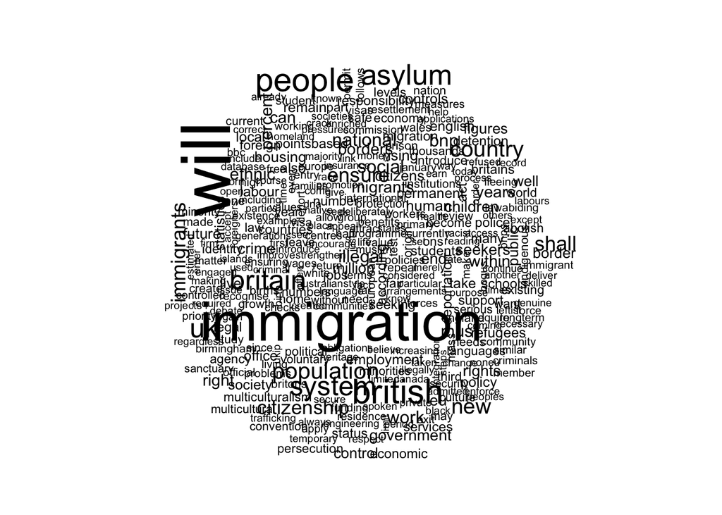

```r
quartz()
plot(mydfm)             # word cloud
```